# index

Christine Dunbar

2025-07-24

## Questions and Hypotheses

Research question: what is determining muskox occurrence throughout TDN? Is it predation, or food, or thermoregulation, or abiotic factors? Or maybe is it a mix of different environmental components (predation, landcover, post-fire vegetation age, or abiotic factors)?

I hypothesise that muskox will be influenced by predation and fire in TDN. Previously, I hypothesized snow cover, tree cover and elevation would influence them. After doing some more research, talking with lab mates and my supervisors, I changed my hypotheses.

## Looking at different model selection methods

I will be looking at four different model selection methods in this document: StepAIC, the hypothesis driven approach, dredging and model averaging. I chose these methods as they have been brought up in past conversations with lab mates, advisers, and in articles that have performed similar research. I wanted to explore these different methods to help me get a better understanding of how each one works, and how they differ from one another. I also think it helps me overall understand my data better.

## Packages

Load in packages.

**Click to show/hide packages**

```r
library(vcd)
library(lme4)
```

```r
library(MuMIn)
library(corrplot)
library(glmmTMB)
library(performance)
library(broom.mixed)
library(stringr)
library(flextable)
library(MASS)
library(car)
library(tidyverse)
library(buildmer)
library(sf)
library(ggplot2)
```

## Dataset

Load in my dataset called model_variables.

**Click to show/hide code**

```r
model_variables <- readRDS("~/Desktop/Analysis/Learning/learning/RDS files/model_variables.rds")

model_variables_filtered <- model_variables %>%
  filter(season == "Summer") %>%
  st_drop_geometry()
```

## First Hypothesis Driven Approach

Trying the hypothesis driven approach, but first I’m going to look at different hypotheses compared to my original hypotheses. I will look at predation, land cover, fire and topography models instead of my original hypotheses: predation, food and thermoregulation. I’m looking at this because my original models shared some of the same variables, like fire age. Both my food and thermoregulation hypotheses had fire ages 0, 1, 2, 3. So for this approach, I don’t want any of the same variables to overlap with other models. I think this will help me better understand what is actually causing muskox occurrence in TDN.

Pros:

- Already put thought into what variables you should have, and what combinations there should be
- Good for making inferences as to what matters to a species; driven by knowledge of their biology

Cons:

- Could be missing a combination of variables that is important

The best fitting model of my ‘First Hypothesis Driven Approach’ based on the code output is predation (mod2_pred_sum_2).

The main outcome from this approach:

- Muskox detections are driven primarily by predators
- Muskox detections are driven by time since fire (fire_age1)
- Muskox are selecting against shrub land cover
- Muskox are selecting against higher terrain ruggedness

```r
mod2_null_sum_1 <- glmmTMB(Muskox ~ 1+ offset(log(N_days_effort)) + (1|cluster), family="nbinom2", data = model_variables  %>% filter(season == "Summer"))

#summer predation
mod2_pred_sum_2 <- glmmTMB(Muskox ~ scale(Predators) + offset(log(N_days_effort)) + (1|cluster),
                          family="nbinom2", data = model_variables %>% filter(season == "Summer")) #both grizz and wolf

#summer land cover (ground cover is herbs + bryoids combined)
mod2_landcover_sum_3 <- glmmTMB(Muskox ~ scale(Shrub) + scale(Groundcover) + scale(Water) +
                            offset(log(N_days_effort)) + (1|cluster), family="nbinom2", data = model_variables %>% filter(season == "Summer"))

mod2_landcover_sum_3.1 <- glmmTMB(Muskox ~ scale(Shrub) +
                              offset(log(N_days_effort)) + (1|cluster), family="nbinom2", data = model_variables %>% filter(season == "Summer")) #running model with just shrub variable (estimate: -0.25)

mod2_landcover_sum_3.2 <- glmmTMB(Muskox ~ scale(Groundcover) +
                            offset(log(N_days_effort)) + (1|cluster), family="nbinom2", data = model_variables %>% filter(season == "Summer")) #running model with just herbs variable (estimate: 0.078)

mod2_landcover_sum_3.3 <- glmmTMB(Muskox ~ scale(Water) +
                            offset(log(N_days_effort)) + (1|cluster), family="nbinom2", data = model_variables %>% filter(season == "Summer")) #running model with just herbs variable (estimate: 0.078)

#summer fire
mod2_fire_sum_4 <- glmmTMB(Muskox ~ scale(fire_age1) + scale(fire_age2) + scale(fire_age3) + scale(fire_age0) +
                              offset(log(N_days_effort)) + (1|cluster), family="nbinom2", data = model_variables %>% filter(season == "Summer")) #running just fire variables for food hypothesis

mod2_fire_sum_4.1 <- glmmTMB(Muskox ~ scale(fire_age1) +
                              offset(log(N_days_effort)) + (1|cluster), family="nbinom2", data = model_variables %>% filter(season == "Summer")) #running model with just fire_age1 variable (estimate: 0.2134)

mod2_fire_sum_4.2 <- glmmTMB(Muskox ~ scale(fire_age3) +
                              offset(log(N_days_effort)) + (1|cluster), family="nbinom2", data = model_variables %>% filter(season == "Summer")) #running model with just fire_age3 variable (estimate: 0.008601)

mod2_fire_sum_4.3 <- glmmTMB(Muskox ~ scale(fire_age0) +
                              offset(log(N_days_effort)) + (1|cluster), family="nbinom2", data = model_variables %>% filter(season == "Summer")) #running model with just fire_age0 variable (estimate: -0.04603)

mod2_fire_sum_4.4 <- glmmTMB(Muskox ~ scale(fire_age2) +
                              offset(log(N_days_effort)) + (1|cluster), family="nbinom2", data = model_variables %>% filter(season == "Summer")) #running model with just fire_age0 variable (estimate: -0.04603)

#summer topo
mod2_topo_sum_5 <- glmmTMB(Muskox ~ scale(log_esker_camera_distances) + scale(TRI_extracted) + scale(Arctic_DEM_500m_elevation_m) +
                             offset(log(N_days_effort)) + (1|cluster), family="nbinom2", data = model_variables %>% filter(season == "Summer")) #all variables I think support thermoregulation hypothesis

mod2_topo_sum_5.1 <- glmmTMB(Muskox ~ scale(log_esker_camera_distances) +
                               offset(log(N_days_effort)) + (1|cluster), family="nbinom2", data = model_variables %>% filter(season == "Summer")) #running model with just water variable (estimate: 0.08528)

mod2_topo_sum_5.2 <- glmmTMB(Muskox ~ scale(TRI_extracted) +
                               offset(log(N_days_effort)) + (1|cluster), family="nbinom2", data = model_variables %>% filter(season == "Summer")) #running model with just log_esker_camera_distances variable (estimate: 0.01676)

mod2_topo_sum_5.3 <- glmmTMB(Muskox ~ scale(Arctic_DEM_500m_elevation_m) +
                               offset(log(N_days_effort)) + (1|cluster), family="nbinom2", data = model_variables %>% filter(season == "Summer")) #running model with just water variable (estimate: 0.08528)


#global model
mod2_global <- glmmTMB(Muskox ~ scale(log_esker_camera_distances) + scale(TRI_extracted) + scale(fire_age1) + scale(fire_age2) + scale(fire_age3) + scale(fire_age0) + scale(Arctic_DEM_500m_elevation_m) + scale(Shrub) + scale(Groundcover) + scale(Predators) + scale(Water) +
                             offset(log(N_days_effort)) + (1|cluster), family="nbinom2", data = model_variables %>% filter(season == "Summer"))

fmListAll2 <- model.sel(mod2_null_sum_1=mod2_null_sum_1,mod2_pred_sum_2=mod2_pred_sum_2,mod2_landcover_sum_3=mod2_landcover_sum_3, mod2_landcover_sum_3.1=mod2_landcover_sum_3.1, mod2_landcover_sum_3.2=mod2_landcover_sum_3.2, mod2_landcover_sum_3.3=mod2_landcover_sum_3.3, mod2_fire_sum_4=mod2_fire_sum_4, mod2_fire_sum_4.1=mod2_fire_sum_4.1, mod2_fire_sum_4.2=mod2_fire_sum_4.2, mod2_fire_sum_4.3=mod2_fire_sum_4.3, mod2_fire_sum_4.4=mod2_fire_sum_4.4, mod2_topo_sum_5=mod2_topo_sum_5,mod2_topo_sum_5.1=mod2_topo_sum_5.1, mod2_topo_sum_5.2=mod2_topo_sum_5.2, mod2_topo_sum_5.3=mod2_topo_sum_5.3, mod2_global=mod2_global)

fmListAll2
```

```
## Model selection table
##                        cnd((Int)) dsp((Int)) cnd(off(log(N_dys_eff)))
## mod2_pred_sum_2            -4.611          +                        +
## mod2_global                -4.618          +                        +
## mod2_topo_sum_5            -4.610          +                        +
## mod2_landcover_sum_3.1     -4.598          +                        +
## mod2_topo_sum_5.2          -4.623          +                        +
## mod2_fire_sum_4.1          -4.608          +                        +
## mod2_fire_sum_4.4          -4.626          +                        +
## mod2_landcover_sum_3.3     -4.613          +                        +
## mod2_landcover_sum_3       -4.603          +                        +
## mod2_topo_sum_5.3          -4.599          +                        +
## mod2_null_sum_1            -4.607          +                        +
## mod2_fire_sum_4            -4.626          +                        +
## mod2_fire_sum_4.3          -4.606          +                        +
## mod2_topo_sum_5.1          -4.605          +                        +
## mod2_fire_sum_4.2          -4.607          +                        +
## mod2_landcover_sum_3.2     -4.607          +                        +
##                        cnd(scl(Prd)) cnd(scl(Grn)) cnd(scl(Shr)) cnd(scl(Wtr))
## mod2_pred_sum_2              0.10800
## mod2_global                  0.09884    -0.0536600       -0.2510      -0.01129
## mod2_topo_sum_5
## mod2_landcover_sum_3.1                                   -0.2440
## mod2_topo_sum_5.2
## mod2_fire_sum_4.1
## mod2_fire_sum_4.4
## mod2_landcover_sum_3.3                                                 0.10030
## mod2_landcover_sum_3                    -0.0420900       -0.2201       0.06255
## mod2_topo_sum_5.3
## mod2_null_sum_1
## mod2_fire_sum_4
## mod2_fire_sum_4.3
## mod2_topo_sum_5.1
## mod2_fire_sum_4.2
## mod2_landcover_sum_3.2                  -0.0009667
##                        cnd(scl(fir_ag0)) cnd(scl(fir_ag1)) cnd(scl(fir_ag2))
## mod2_pred_sum_2
## mod2_global                     -0.04109            0.1835           -0.1699
## mod2_topo_sum_5
## mod2_landcover_sum_3.1
```

[output cut: 51 more lines]

```
## mod2_topo_sum_5.2      4206.8  3.56  0.056
## mod2_fire_sum_4.1      4207.0  3.77  0.051
## mod2_fire_sum_4.4      4207.5  4.27  0.039
## mod2_landcover_sum_3.3 4208.0  4.82  0.030
## mod2_landcover_sum_3   4208.3  5.13  0.026
## mod2_topo_sum_5.3      4208.9  5.64  0.020
## mod2_null_sum_1        4209.2  6.02  0.016
## mod2_fire_sum_4        4209.8  6.54  0.013
## mod2_fire_sum_4.3      4211.1  7.90  0.006
## mod2_topo_sum_5.1      4211.2  7.97  0.006
## mod2_fire_sum_4.2      4211.2  8.00  0.006
## mod2_landcover_sum_3.2 4211.2  8.02  0.006
## Models ranked by AICc(x)
## Random terms (all models):
##   cond(1 | cluster)
```

```r
#best fitting model for first hypothesis driven approach is predation
summary(mod2_pred_sum_2)
```

```
##  Family: nbinom2  ( log )
## Formula:
## Muskox ~ scale(Predators) + offset(log(N_days_effort)) + (1 |      cluster)
## Data: model_variables %>% filter(season == "Summer")
##
##       AIC       BIC    logLik -2*log(L)  df.resid
##    4203.2    4230.8   -2097.6    4195.2      7255
##
## Random effects:
##
## Conditional model:
##  Groups  Name        Variance Std.Dev.
##  cluster (Intercept) 0.7279   0.8532
## Number of obs: 7259, groups:  cluster, 60
##
## Dispersion parameter for nbinom2 family (): 0.194
##
## Conditional model:
##                  Estimate Std. Error z value Pr(>|z|)
## (Intercept)      -4.61087    0.12745  -36.18  < 2e-16 ***
## scale(Predators)  0.10799    0.04051    2.67  0.00768 **
## ---
## Signif. codes:  0 '***' 0.001 '**' 0.01 '*' 0.05 '.' 0.1 ' ' 1
```

```r
#global model is also competitive with top model for first hypothesis driven approach
summary(mod2_global)
```

```
##  Family: nbinom2  ( log )
## Formula:
## Muskox ~ scale(log_esker_camera_distances) + scale(TRI_extracted) +
##     scale(fire_age1) + scale(fire_age2) + scale(fire_age3) +
##     scale(fire_age0) + scale(Arctic_DEM_500m_elevation_m) + scale(Shrub) +
##     scale(Groundcover) + scale(Predators) + scale(Water) + offset(log(N_days_effort)) +
##     (1 | cluster)
## Data: model_variables %>% filter(season == "Summer")
##
##       AIC       BIC    logLik -2*log(L)  df.resid
##    4204.1    4300.6   -2088.1    4176.1      7245
##
## Random effects:
##
## Conditional model:
##  Groups  Name        Variance Std.Dev.
##  cluster (Intercept) 0.5819   0.7628
## Number of obs: 7259, groups:  cluster, 60
##
## Dispersion parameter for nbinom2 family (): 0.196
##
## Conditional model:
##                                     Estimate Std. Error z value Pr(>|z|)
## (Intercept)                        -4.617866   0.117910  -39.16   <2e-16 ***
## scale(log_esker_camera_distances)   0.024794   0.127400    0.19   0.8457
## scale(TRI_extracted)               -0.260625   0.129101   -2.02   0.0435 *
## scale(fire_age1)                    0.183495   0.103906    1.77   0.0774 .
## scale(fire_age2)                   -0.169910   0.145302   -1.17   0.2423
## scale(fire_age3)                   -0.002659   0.106430   -0.02   0.9801
## scale(fire_age0)                   -0.041093   0.113847   -0.36   0.7181
## scale(Arctic_DEM_500m_elevation_m) -0.169070   0.140417   -1.20   0.2286
## scale(Shrub)                       -0.250982   0.133158   -1.88   0.0595 .
## scale(Groundcover)                 -0.053664   0.099800   -0.54   0.5908
## scale(Predators)                    0.098841   0.040587    2.44   0.0149 *
## scale(Water)                       -0.011294   0.063748   -0.18   0.8594
## ---
## Signif. codes:  0 '***' 0.001 '**' 0.01 '*' 0.05 '.' 0.1 ' ' 1
```

## Plotting predation coefficients estimates

Plotting the coefficient estimates to visually see what variables are significant. In this example, I am plotting the coefficient estimates for the predation model (mod2_pred_sum_2) from the first hypothesis driven approach.

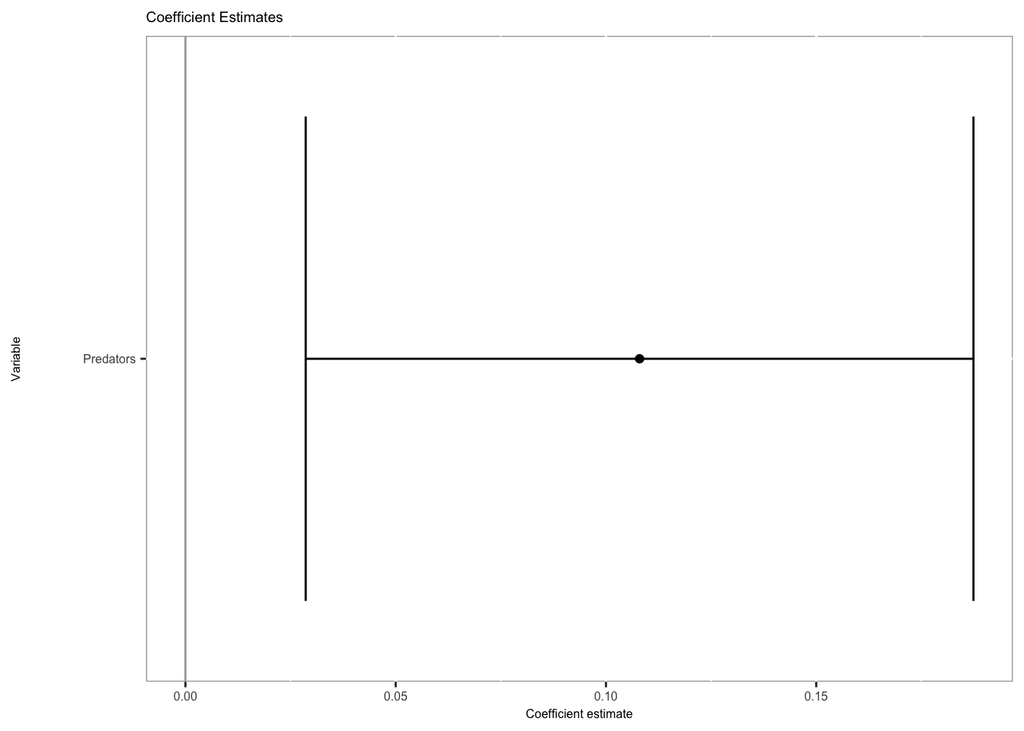

```r
#Get summary object
sum <- summary(mod2_pred_sum_2)

#Extract coefficients for the mean model
coef_table_pred <- coef(sum)$cond

#Turn into a data frame
coefficients_df_pred <- as.data.frame(coef_table_pred)
coefficients_df_pred$Variable <- rownames(coef_table_pred)
rownames(coefficients_df_pred) <- NULL

#renaming column
coefficients_df_pred <- coefficients_df_pred %>%
rename(Std.Error = `Std. Error`)

#Add confidence intervals
coefficients_df_pred <- coefficients_df_pred %>%
mutate(
Lower = Estimate - 1.96 * Std.Error,
Upper = Estimate + 1.96 * Std.Error)

#Rename categories
comp3pred <- coefficients_df_pred %>%
mutate(Variable = as.character(Variable)) %>%
mutate(Variable = dplyr::recode(Variable,
"scale(log_esker_camera_distances)" = "Distance to Esker",
"scale(TRI_extracted)" = "Terrain Ruggedness",
"scale(fire_age0)" = "0-10 Years Post Fire",
"scale(fire_age1)" = "11-20 Years Post Fire",
"scale(fire_age2)" = "21-30 Years Post Fire",
"scale(fire_age3)" = "31-50 Years Post Fire",
"scale(Arctic_DEM_500m_elevation_m)" = "Elevation",
"scale(Shrub)" = "Shrub",
"scale(Groundcover)" = "Groundcover",
"scale(Predators)" = "Predators",
"scale(Water)" = "Water",
"(Intercept)"="Intercept"))

#Specify the desired order of categories
desired_order5pred <- c("Distance to Esker",
"Elevation",
"Groundcover",
"Predators",
"Shrub",
"Terrain Ruggedness",
"11-20 Years Post Fire",
"21-30 Years Post Fire",
"31-50 Years Post Fire",
"0-10 Years Post Fire",
"Water",
"Intercept")

#Reorder the factor levels in the data frame
comp3pred$Variable <- factor(comp3pred$Variable, levels = desired_order5pred)

#Reorder factor to put Intercept last (bottom of plot)
comp3pred$Variable <- factor(comp3pred$Variable, levels = c(
  setdiff(unique(comp3pred$Variable), "Intercept"), "Intercept"
))

# Remove the Intercept (for now)
comp3pred <- comp3pred %>% filter(Variable != "Intercept")

# Then plot
coef_estimates_pred <- ggplot(comp3pred, aes(x = Variable, y = Estimate)) +
  geom_hline(yintercept = 0, col = "darkgrey") +  # Horizontal line at y = 0
  geom_point() +
  geom_errorbar(aes(ymin = Lower, ymax = Upper)) +
  coord_flip() +
  labs(x = "Variable", y = "Coefficient estimate", title = "Coefficient Estimates") +
  theme(
    axis.title.y = element_text(margin = margin(t = 0, r = 30, b = 0, l = 0)),
    panel.background = element_rect(fill = 'white', colour = 'darkgrey'),
    panel.grid.major = element_line(colour = 'white'),
    text = element_text(size = 6),  # Increase overall font size
    axis.title = element_text(size = 6),  # Axis titles
    axis.text = element_text(size = 6)   # Axis text
  )

#Save the plot (pdf)
ggsave(
filename = "./Plots/coef_estimates_pred.pdf",
plot = coef_estimates_pred,
device = "pdf", height = 10, width = 17,
units = "cm")

#Save the plot (jpeg)
ggsave(
filename = "./Plots/coef_estimates_pred.jpg",
plot = coef_estimates_pred,
device = "jpg", height = 10, width = 17,
units = "cm")

coef_estimates_pred
```

## Plotting mod2_global coefficients estimates

Plotting the coefficient estimates to visually see what variables are significant. In this example, I am plotting the coefficient estimates for the global model (mod2_global) from the first hypothesis driven approach. My second best fitting model.

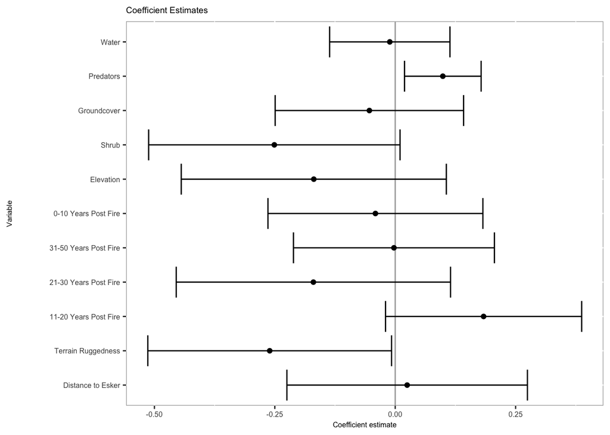

```r
#Get summary object
sum <- summary(mod2_global)

#Extract coefficients for the mean model
coef_table <- coef(sum)$cond

#Turn into a data frame
coefficients_df <- as.data.frame(coef_table)
coefficients_df$Variable <- rownames(coef_table)
rownames(coefficients_df) <- NULL

#renaming column
coefficients_df <- coefficients_df %>%
rename(Std.Error = `Std. Error`)

#Add confidence intervals
coefficients_df <- coefficients_df %>%
mutate(
Lower = Estimate - 1.96 * Std.Error,
Upper = Estimate + 1.96 * Std.Error)

#Rename categories
comp3 <- coefficients_df %>%
mutate(Variable = as.character(Variable)) %>%
mutate(Variable = dplyr::recode(Variable,
"scale(log_esker_camera_distances)" = "Distance to Esker",
"scale(TRI_extracted)" = "Terrain Ruggedness",
"scale(fire_age0)" = "0-10 Years Post Fire",
"scale(fire_age1)" = "11-20 Years Post Fire",
"scale(fire_age2)" = "21-30 Years Post Fire",
"scale(fire_age3)" = "31-50 Years Post Fire",
"scale(Arctic_DEM_500m_elevation_m)" = "Elevation",
"scale(Shrub)" = "Shrub",
"scale(Groundcover)" = "Groundcover",
"scale(Predators)" = "Predators",
"scale(Water)" = "Water",
"(Intercept)"="Intercept"))

#Specify the desired order of categories
desired_order5 <- c("Distance to Esker",
"Elevation",
"Groundcover",
"Predators",
"Shrub",
"Terrain Ruggedness",
"11-20 Years Post Fire",
"21-30 Years Post Fire",
"31-50 Years Post Fire",
"0-10 Years Post Fire",
"Water",
"Intercept")

#Reorder the factor levels in the data frame
comp3$Variable <- factor(comp3$Variable, levels = desired_order5)

#Reorder factor to put Intercept last (bottom of plot)
comp3$Variable <- factor(comp3$Variable, levels = c(
  setdiff(unique(comp3$Variable), "Intercept"), "Intercept"
))

# Remove the Intercept
comp3 <- comp3 %>% filter(Variable != "Intercept")

# Then plot
coef_estimates <- ggplot(comp3, aes(x = Variable, y = Estimate)) +
  geom_hline(yintercept = 0, col = "darkgrey") +  # Horizontal line at y = 0
  geom_point() +
  geom_errorbar(aes(ymin = Lower, ymax = Upper)) +
  coord_flip() +
  labs(x = "Variable", y = "Coefficient estimate", title = "Coefficient Estimates") +
  theme(
    axis.title.y = element_text(margin = margin(t = 0, r = 30, b = 0, l = 0)),
    panel.background = element_rect(fill = 'white', colour = 'darkgrey'),
    panel.grid.major = element_line(colour = 'white'),
    text = element_text(size = 6),  # Increase overall font size
    axis.title = element_text(size = 6),  # Axis titles
    axis.text = element_text(size = 6)   # Axis text
  )

#Save the plot (pdf)
ggsave(
filename = "./Plots/coef_estimates.pdf",
plot = coef_estimates,
device = "pdf", height = 10, width = 17,
units = "cm")

#Save the plot (jpeg)
ggsave(
filename = "./Plots/coef_estimates.jpg",
plot = coef_estimates,
device = "jpg", height = 10, width = 17,
units = "cm")

coef_estimates
```

## Second Hypothesis Driven Approach

Lets look at using the hypothesis driven approach on my global summer models but with my original hypotheses: predation, food and theromregulation.

```r
mod_null_all_1 <- glmmTMB(Muskox ~ 1+ offset(log(N_days_effort)) + (1|cluster), family="nbinom2", data = model_variables  %>% filter(season == "Summer"))

#summer predation
mod_pred_sum_1 <- glmmTMB(Muskox ~ scale(Predators) + offset(log(N_days_effort)) + (1|cluster),
                          family="nbinom2", data = model_variables %>% filter(season == "Summer")) #both grizz and wolf

#summer food
mod_food_sum_3 <- glmmTMB(Muskox ~ scale(Shrub) + scale(Groundcover) + scale(fire_age1) + scale(fire_age3) + scale(fire_age0) + scale(fire_age2) +
                            offset(log(N_days_effort)) + (1|cluster), family="nbinom2", data = model_variables %>% filter(season == "Summer"))

mod_food_sum_3.1 <- glmmTMB(Muskox ~ scale(Shrub) +
                              offset(log(N_days_effort)) + (1|cluster), family="nbinom2", data = model_variables %>% filter(season == "Summer")) #running model with just shrub variable (estimate: -0.25)

mod_food_sum_3.2 <- glmmTMB(Muskox ~ scale(Groundcover) +
                            offset(log(N_days_effort)) + (1|cluster), family="nbinom2", data = model_variables %>% filter(season == "Summer")) #running model with just herbs variable (estimate: 0.078)

mod_food_sum_3.3 <- glmmTMB(Muskox ~ scale(fire_age1) +
                              offset(log(N_days_effort)) + (1|cluster), family="nbinom2", data = model_variables %>% filter(season == "Summer")) #running model with just fire_age1 variable (estimate: 0.2134)

mod_food_sum_3.4 <- glmmTMB(Muskox ~ scale(fire_age3) +
                              offset(log(N_days_effort)) + (1|cluster), family="nbinom2", data = model_variables %>% filter(season == "Summer")) #running model with just fire_age3 variable (estimate: 0.008601)

mod_food_sum_3.5 <- glmmTMB(Muskox ~ scale(fire_age2) +
                              offset(log(N_days_effort)) + (1|cluster), family="nbinom2", data = model_variables %>% filter(season == "Summer")) #running model with just fire_age0 variable (estimate: -0.04603)

mod_food_sum_3.6 <- glmmTMB(Muskox ~ scale(fire_age0) +
                              offset(log(N_days_effort)) + (1|cluster), family="nbinom2", data = model_variables %>% filter(season == "Summer"))

mod_food_sum_3.7 <- glmmTMB(Muskox ~ scale(Shrub) + scale(Groundcover) +
                               offset(log(N_days_effort)) + (1|cluster), family="nbinom2", data = model_variables %>% filter(season == "Summer")) #running just vegetation variables for food

mod_food_sum_3.8 <- glmmTMB(Muskox ~ scale(fire_age1) + scale(fire_age2) + scale(fire_age3) + scale(fire_age0) +
                              offset(log(N_days_effort)) + (1|cluster), family="nbinom2", data = model_variables %>% filter(season == "Summer")) #running just fire variables for food hypothesis


#summer thermoregulation
mod_therm_sum_4 <- glmmTMB(Muskox ~ scale(Water) + scale(log_esker_camera_distances) + scale(TRI_extracted) + scale(fire_age1) + scale(fire_age2) + scale(fire_age3) + scale(fire_age0) + scale(Arctic_DEM_500m_elevation_m) +
                             offset(log(N_days_effort)) + (1|cluster), family="nbinom2", data = model_variables %>% filter(season == "Summer")) #all variables I think support thermoregulation hypothesis

mod_therm_sum_4.1 <- glmmTMB(Muskox ~ scale(`Water`) +
                               offset(log(N_days_effort)) + (1|cluster), family="nbinom2", data = model_variables %>% filter(season == "Summer")) #running model with just water variable (estimate: 0.08528)

mod_therm_sum_4.2 <- glmmTMB(Muskox ~ scale(`log_esker_camera_distances`) +
                               offset(log(N_days_effort)) + (1|cluster), family="nbinom2", data = model_variables %>% filter(season == "Summer")) #running model with just log_esker_camera_distances variable (estimate: 0.01676)

mod_therm_sum_4.3 <- glmmTMB(Muskox ~ scale(TRI_extracted)+
                               offset(log(N_days_effort)) + (1|cluster), family="nbinom2", data = model_variables %>% filter(season == "Summer")) #running model with just water variable (estimate: 0.08528)

mod_therm_sum_4.4 <- glmmTMB(Muskox ~ scale(Arctic_DEM_500m_elevation_m) +
                             offset(log(N_days_effort)) + (1|cluster), family="nbinom2", data = model_variables %>% filter(season == "Summer")) #all variables I think support thermoregulation hypothesis

mod_therm_sum_4.5 <- glmmTMB(Muskox ~ scale(Water) + scale(log_esker_camera_distances) + scale(TRI_extracted) + scale(Arctic_DEM_500m_elevation_m) +
                             offset(log(N_days_effort)) + (1|cluster), family="nbinom2", data = model_variables %>% filter(season == "Summer")) #all variables I think support thermoregulation hypothesis


mod_global <- glmmTMB(Muskox ~ scale(Water) + scale(log_esker_camera_distances) + scale(TRI_extracted) + scale(fire_age1) + scale(fire_age2) + scale(fire_age3) + scale(fire_age0) + scale(Arctic_DEM_500m_elevation_m) + scale(Shrub) + scale(Groundcover) + scale(Predators) +
                             offset(log(N_days_effort)) + (1|cluster), family="nbinom2", data = model_variables %>% filter(season == "Summer"))

fmListAll <- model.sel(mod_null_all_1=mod_null_all_1, mod_pred_sum_1=mod_pred_sum_1, mod_food_sum_3=mod_food_sum_3, mod_food_sum_3.1=mod_food_sum_3.1, mod_food_sum_3.2=mod_food_sum_3.2, mod_food_sum_3.3=mod_food_sum_3.3, mod_food_sum_3.4=mod_food_sum_3.4, mod_food_sum_3.5=mod_food_sum_3.5, mod_food_sum_3.6=mod_food_sum_3.6, mod_food_sum_3.7=mod_food_sum_3.7, mod_food_sum_3.8=mod_food_sum_3.8, mod_therm_sum_4=mod_therm_sum_4, mod_therm_sum_4.1=mod_therm_sum_4.1,
                     mod_therm_sum_4.2=mod_therm_sum_4.2, mod_therm_sum_4.3=mod_therm_sum_4.3, mod_therm_sum_4.4=mod_therm_sum_4.4,mod_therm_sum_4.5=mod_therm_sum_4.5,mod_global=mod_global)

fmListAll
```

```
## Model selection table
##                   cnd((Int)) dsp((Int)) cnd(off(log(N_dys_eff))) cnd(scl(Prd))
## mod_pred_sum_1        -4.611          +                        +       0.10800
## mod_global            -4.618          +                        +       0.09884
## mod_food_sum_3.1      -4.598          +                        +
## mod_food_sum_3        -4.617          +                        +
## mod_therm_sum_4.3     -4.623          +                        +
## mod_therm_sum_4.5     -4.612          +                        +
## mod_food_sum_3.3      -4.608          +                        +
## mod_food_sum_3.5      -4.626          +                        +
## mod_food_sum_3.7      -4.598          +                        +
## mod_therm_sum_4.1     -4.613          +                        +
## mod_therm_sum_4       -4.621          +                        +
## mod_therm_sum_4.4     -4.599          +                        +
## mod_null_all_1        -4.607          +                        +
## mod_food_sum_3.8      -4.626          +                        +
## mod_food_sum_3.6      -4.606          +                        +
## mod_therm_sum_4.2     -4.605          +                        +
## mod_food_sum_3.4      -4.607          +                        +
## mod_food_sum_3.2      -4.607          +                        +
##                   cnd(scl(fir_ag0)) cnd(scl(fir_ag1)) cnd(scl(fir_ag2))
## mod_pred_sum_1
## mod_global                 -0.04109            0.1835           -0.1699
## mod_food_sum_3.1
## mod_food_sum_3             -0.06458            0.1600           -0.2925
## mod_therm_sum_4.3
## mod_therm_sum_4.5
## mod_food_sum_3.3                               0.2183
## mod_food_sum_3.5                                                -0.2480
## mod_food_sum_3.7
## mod_therm_sum_4.1
## mod_therm_sum_4            -0.03375            0.2271           -0.1369
## mod_therm_sum_4.4
## mod_null_all_1
## mod_food_sum_3.8           -0.05441            0.2044           -0.2250
## mod_food_sum_3.6           -0.04278
## mod_therm_sum_4.2
## mod_food_sum_3.4
## mod_food_sum_3.2
##                   cnd(scl(fir_ag3)) cnd(scl(Grn)) cnd(scl(Shr))
```

[output cut: 63 more lines]

```
## mod_food_sum_3.3   0.047
## mod_food_sum_3.5   0.037
## mod_food_sum_3.7   0.037
## mod_therm_sum_4.1  0.028
## mod_therm_sum_4    0.022
## mod_therm_sum_4.4  0.019
## mod_null_all_1     0.015
## mod_food_sum_3.8   0.012
## mod_food_sum_3.6   0.006
## mod_therm_sum_4.2  0.006
## mod_food_sum_3.4   0.006
## mod_food_sum_3.2   0.006
## Models ranked by AICc(x)
## Random terms (all models):
##   cond(1 | cluster)
```

```r
#mod_pred_sum_1 is the best fitting model for the second hypothesis driven approach
summary(mod_pred_sum_1)
```

```
##  Family: nbinom2  ( log )
## Formula:
## Muskox ~ scale(Predators) + offset(log(N_days_effort)) + (1 |      cluster)
## Data: model_variables %>% filter(season == "Summer")
##
##       AIC       BIC    logLik -2*log(L)  df.resid
##    4203.2    4230.8   -2097.6    4195.2      7255
##
## Random effects:
##
## Conditional model:
##  Groups  Name        Variance Std.Dev.
##  cluster (Intercept) 0.7279   0.8532
## Number of obs: 7259, groups:  cluster, 60
##
## Dispersion parameter for nbinom2 family (): 0.194
##
## Conditional model:
##                  Estimate Std. Error z value Pr(>|z|)
## (Intercept)      -4.61087    0.12745  -36.18  < 2e-16 ***
## scale(Predators)  0.10799    0.04051    2.67  0.00768 **
## ---
## Signif. codes:  0 '***' 0.001 '**' 0.01 '*' 0.05 '.' 0.1 ' ' 1
```

```r
#global model is also competitive with top model for the second hypothesis driven approach
summary(mod_global)
```

```
##  Family: nbinom2  ( log )
## Formula:
## Muskox ~ scale(Water) + scale(log_esker_camera_distances) + scale(TRI_extracted) +
##     scale(fire_age1) + scale(fire_age2) + scale(fire_age3) +
##     scale(fire_age0) + scale(Arctic_DEM_500m_elevation_m) + scale(Shrub) +
##     scale(Groundcover) + scale(Predators) + offset(log(N_days_effort)) +
##     (1 | cluster)
## Data: model_variables %>% filter(season == "Summer")
##
##       AIC       BIC    logLik -2*log(L)  df.resid
##    4204.1    4300.6   -2088.1    4176.1      7245
##
## Random effects:
##
## Conditional model:
##  Groups  Name        Variance Std.Dev.
##  cluster (Intercept) 0.5819   0.7628
## Number of obs: 7259, groups:  cluster, 60
##
## Dispersion parameter for nbinom2 family (): 0.196
##
## Conditional model:
##                                     Estimate Std. Error z value Pr(>|z|)
## (Intercept)                        -4.617866   0.117910  -39.16   <2e-16 ***
## scale(Water)                       -0.011294   0.063748   -0.18   0.8594
## scale(log_esker_camera_distances)   0.024794   0.127400    0.19   0.8457
## scale(TRI_extracted)               -0.260625   0.129101   -2.02   0.0435 *
## scale(fire_age1)                    0.183495   0.103906    1.77   0.0774 .
## scale(fire_age2)                   -0.169910   0.145302   -1.17   0.2423
## scale(fire_age3)                   -0.002659   0.106430   -0.02   0.9801
## scale(fire_age0)                   -0.041093   0.113847   -0.36   0.7181
## scale(Arctic_DEM_500m_elevation_m) -0.169070   0.140417   -1.20   0.2286
## scale(Shrub)                       -0.250982   0.133158   -1.88   0.0595 .
## scale(Groundcover)                 -0.053664   0.099800   -0.54   0.5908
## scale(Predators)                    0.098841   0.040587    2.44   0.0149 *
## ---
## Signif. codes:  0 '***' 0.001 '**' 0.01 '*' 0.05 '.' 0.1 ' ' 1
```

## StepAIC

Lets look at using StepAIC on my global summer models.

Pros to using StepAIC:

- Minimizes model complexity
- Enhance model performance by removing irrelevant variables
- Appropriate to make a predictive model/estimating distribution

Cons to using StepAIC:

- “By passing the hard thinking”
- No theory underlying the approach
- Sensitive to the order of variable entry and removal
- Can create biased estimates, standard errors, inflated p-value, and confidence intervals
- This method does not work well with the glmmTMB package, which is what I am using. I tried to use the glm.nb package for my models but I was getting convergence errors, and when I switched to the glmmTMB package, all my models ran.

```r
#scaling the variables.

model_data <- model_variables %>% filter(season == "Summer" )
z_model_data <- MuMIn::stdize(model_data) # standarized covariates

#adding the scaled variables to dataset
model_data <- model_data %>%
  left_join(z_model_data)
#original model with all variables. fire_age2 was removed due to high collinearity with fire_age4, and trees removed due to high collinearity with shrub
mod_global_shrub <- buildglmmTMB(Muskox ~ z.log_esker_camera_distances + z.fire_age3 + z.fire_age0 + scale(fire_age1) + scale(fire_age2) + scale(Shrub) + scale(Groundcover) + scale(Predators) + scale(Water) + scale(TRI_extracted) + scale(Arctic_DEM_500m_elevation_m) +
                                 (1|cluster) + offset(log(N_days_effort)), family="nbinom2", data = model_data,
                                 buildmerControl = buildmerControl(crit = "AIC", direction = "backward", calc.anova = TRUE, include = ~ (1|cluster) + offset(log(N_days_effort))))
```

[output not shown]

[output cut: 12 more lines]

[output not shown]

```
##    grouping                               term
## 1      <NA>         offset(log(N_days_effort))
## 2      <NA>                                  1
## 3      <NA>       z.log_esker_camera_distances
## 4      <NA>                        z.fire_age3
## 5      <NA>                        z.fire_age0
## 6      <NA>                   scale(fire_age1)
## 7      <NA>                   scale(fire_age2)
## 8      <NA>                       scale(Shrub)
## 9      <NA>                 scale(Groundcover)
## 10     <NA>                   scale(Predators)
## 11     <NA>                       scale(Water)
## 12     <NA>               scale(TRI_extracted)
## 13     <NA> scale(Arctic_DEM_500m_elevation_m)
## 14  cluster                                  1
##                                       block Iteration          AIC
## 1          NA NA offset(log(N_days_effort))         1           NA
## 2                                   NA NA 1         1           NA
## 3        NA NA z.log_esker_camera_distances         1   -1.0623999
## 4                         NA NA z.fire_age3         1   -4.2810042
## 5                         NA NA z.fire_age0         1          NaN
## 6                    NA NA scale(fire_age1)         1  -44.4211656
## 7                    NA NA scale(fire_age2)         1 -255.7882685
## 8                        NA NA scale(Shrub)         1    1.0359561
## 9                  NA NA scale(Groundcover)         1    0.9096407
## 10                   NA NA scale(Predators)         1  -81.1832530
## 11                       NA NA scale(Water)         1          NaN
## 12               NA NA scale(TRI_extracted)         1  -28.8568305
## 13 NA NA scale(Arctic_DEM_500m_elevation_m)         1  -36.2300729
## 14                             NA cluster 1         1           NA
```

[output not shown]

[output cut: 12 more lines]

[output not shown]

```
##    grouping                               term
## 1      <NA>         offset(log(N_days_effort))
## 2      <NA>                                  1
## 3      <NA>       z.log_esker_camera_distances
## 4      <NA>                        z.fire_age3
## 5      <NA>                        z.fire_age0
## 6      <NA>                   scale(fire_age1)
## 7      <NA>                   scale(fire_age2)
## 9      <NA>                 scale(Groundcover)
## 10     <NA>                   scale(Predators)
## 11     <NA>                       scale(Water)
## 12     <NA>               scale(TRI_extracted)
## 13     <NA> scale(Arctic_DEM_500m_elevation_m)
## 14  cluster                                  1
##                                       block Iteration          AIC
## 1          NA NA offset(log(N_days_effort))         2           NA
## 2                                   NA NA 1         2           NA
## 3        NA NA z.log_esker_camera_distances         2   -1.0789359
## 4                         NA NA z.fire_age3         2   -3.5808710
## 5                         NA NA z.fire_age0         2    1.6071280
## 6                    NA NA scale(fire_age1)         2  -44.3254740
## 7                    NA NA scale(fire_age2)         2 -254.8242664
## 9                  NA NA scale(Groundcover)         2    0.5359818
## 10                   NA NA scale(Predators)         2  -82.1700208
## 11                       NA NA scale(Water)         2    1.1223131
## 12               NA NA scale(TRI_extracted)         2  -28.5399751
## 13 NA NA scale(Arctic_DEM_500m_elevation_m)         2  -37.5450490
## 14                             NA cluster 1         2           NA
```

[output not shown]

```
##    grouping                               term
## 1      <NA>         offset(log(N_days_effort))
## 2      <NA>                                  1
## 3      <NA>       z.log_esker_camera_distances
## 4      <NA>                        z.fire_age3
## 6      <NA>                   scale(fire_age1)
## 7      <NA>                   scale(fire_age2)
## 9      <NA>                 scale(Groundcover)
## 10     <NA>                   scale(Predators)
## 11     <NA>                       scale(Water)
## 12     <NA>               scale(TRI_extracted)
## 13     <NA> scale(Arctic_DEM_500m_elevation_m)
## 14  cluster                                  1
##                                       block Iteration          AIC
## 1          NA NA offset(log(N_days_effort))         3           NA
## 2                                   NA NA 1         3           NA
## 3        NA NA z.log_esker_camera_distances         3   -1.1509493
## 4                         NA NA z.fire_age3         3   -3.7458882
## 6                    NA NA scale(fire_age1)         3  -44.2119951
## 7                    NA NA scale(fire_age2)         3 -257.7314884
## 9                  NA NA scale(Groundcover)         3    0.5794855
## 10                   NA NA scale(Predators)         3  -82.2088171
## 11                       NA NA scale(Water)         3    0.9339703
## 12               NA NA scale(TRI_extracted)         3  -28.3244581
## 13 NA NA scale(Arctic_DEM_500m_elevation_m)         3  -37.4054666
## 14                             NA cluster 1         3           NA
```

[output not shown]

```
##    grouping                               term
## 1      <NA>         offset(log(N_days_effort))
## 2      <NA>                                  1
## 3      <NA>       z.log_esker_camera_distances
## 4      <NA>                        z.fire_age3
## 6      <NA>                   scale(fire_age1)
## 7      <NA>                   scale(fire_age2)
## 9      <NA>                 scale(Groundcover)
## 10     <NA>                   scale(Predators)
## 12     <NA>               scale(TRI_extracted)
## 13     <NA> scale(Arctic_DEM_500m_elevation_m)
## 14  cluster                                  1
##                                       block Iteration          AIC
## 1          NA NA offset(log(N_days_effort))         4           NA
## 2                                   NA NA 1         4           NA
## 3        NA NA z.log_esker_camera_distances         4   -1.2772035
## 4                         NA NA z.fire_age3         4   -2.9549249
## 6                    NA NA scale(fire_age1)         4  -44.1559928
## 7                    NA NA scale(fire_age2)         4 -293.4844582
## 9                  NA NA scale(Groundcover)         4    0.6091563
## 10                   NA NA scale(Predators)         4  -82.1560996
## 12               NA NA scale(TRI_extracted)         4  -27.3334708
## 13 NA NA scale(Arctic_DEM_500m_elevation_m)         4  -36.7724329
## 14                             NA cluster 1         4           NA
```

[output not shown]

```
##    grouping                               term
## 1      <NA>         offset(log(N_days_effort))
## 2      <NA>                                  1
## 3      <NA>       z.log_esker_camera_distances
## 4      <NA>                        z.fire_age3
## 6      <NA>                   scale(fire_age1)
## 7      <NA>                   scale(fire_age2)
## 10     <NA>                   scale(Predators)
## 12     <NA>               scale(TRI_extracted)
## 13     <NA> scale(Arctic_DEM_500m_elevation_m)
## 14  cluster                                  1
##                                       block Iteration         AIC
## 1          NA NA offset(log(N_days_effort))         5          NA
## 2                                   NA NA 1         5          NA
## 3        NA NA z.log_esker_camera_distances         5   -1.466192
## 4                         NA NA z.fire_age3         5   -2.649245
## 6                    NA NA scale(fire_age1)         5  -44.950289
## 7                    NA NA scale(fire_age2)         5 -312.887424
## 10                   NA NA scale(Predators)         5  -81.289548
## 12               NA NA scale(TRI_extracted)         5  -29.712063
## 13 NA NA scale(Arctic_DEM_500m_elevation_m)         5  -39.760416
## 14                             NA cluster 1         5          NA
```

```
## All terms are significant
```

```
## Error in try({ : ANOVA is not available for glmmTMB fits
```

```r
#check_collinearity(mod_global_sum_trees_2)
mod_global_shrub@p$tab
```

```
##    index grouping                               term
## 1   <NA>     <NA>         offset(log(N_days_effort))
## 2   <NA>     <NA>                                  1
## 3   <NA>     <NA>       z.log_esker_camera_distances
## 4   <NA>     <NA>                        z.fire_age3
## 6   <NA>     <NA>                   scale(fire_age1)
## 7   <NA>     <NA>                   scale(fire_age2)
## 10  <NA>     <NA>                   scale(Predators)
## 12  <NA>     <NA>               scale(TRI_extracted)
## 13  <NA>     <NA> scale(Arctic_DEM_500m_elevation_m)
## 14  14 1  cluster                                  1
##                                  code                                    block
## 1          offset(log(N_days_effort))         NA NA offset(log(N_days_effort))
## 2                                   1                                  NA NA 1
## 3        z.log_esker_camera_distances       NA NA z.log_esker_camera_distances
```

[output cut: 18 more lines]

```r
summary(mod_global_shrub)
```

```
##  Family: nbinom2  ( log )
## Formula:
## Muskox ~ offset(log(N_days_effort)) + 1 + z.log_esker_camera_distances +
##     z.fire_age3 + scale(fire_age1) + scale(fire_age2) + scale(Predators) +
##     scale(TRI_extracted) + scale(Arctic_DEM_500m_elevation_m) +
##     (1 | cluster)
## Data: model_data
##
##       AIC       BIC    logLik -2*log(L)  df.resid
##  100495.4  100596.4  -50237.7  100475.4    179905
##
## Random effects:
##
## Conditional model:
##  Groups  Name        Variance Std.Dev.
##  cluster (Intercept) 3.144    1.773
## Number of obs: 179915, groups:  cluster, 60
##
## Dispersion parameter for nbinom2 family (): 0.225
##
## Conditional model:
##                                     Estimate Std. Error z value Pr(>|z|)
## (Intercept)                        -4.877804   0.230662 -21.147  < 2e-16 ***
## z.log_esker_camera_distances       -0.083930   0.044601  -1.882   0.0599 .
## z.fire_age3                        -0.089468   0.041704  -2.145   0.0319 *
## scale(fire_age1)                    0.397572   0.060470   6.575 4.88e-11 ***
## scale(fire_age2)                   -1.087019   0.064108 -16.956  < 2e-16 ***
## scale(Predators)                    0.070628   0.008077   8.745  < 2e-16 ***
## scale(TRI_extracted)               -0.154838   0.028225  -5.486 4.12e-08 ***
## scale(Arctic_DEM_500m_elevation_m) -0.611950   0.094740  -6.459 1.05e-10 ***
## ---
## Signif. codes:  0 '***' 0.001 '**' 0.01 '*' 0.05 '.' 0.1 ' ' 1
```

## Dredging

Pros:

- Lets you see all combinations of the variables
- Lets you see if a combination you haven’t thought of is better than the combination you came up with based on hypotheses
- Appropriate method to make a predictive model/estimating distribution of a species

Cons:

- “By passing the hard thinking”
- This method might find the strongest variables, but doesn’t always mean causation. Need to understand biology behind it!
- When dredging, you increase the chance of finding statistically significant results that are actually due to random chance, rather than a true relationship in the data.

I tried to dredge my models with all the variables in my data set and left it to run for 3 days. After 3 days it was still running, so I stopped it. It usually shouldn’t take that long to dredge. I removed half of the variables in the data set and ran the dredging package again and it worked. But now, half my variables are gone that are important to include. I also received mixed opinions on whether I should use dredging in my models or not, so I took that into consideration with what model selection method I should use.

The code I was using is below but I hashed it out because it was taking a long time to run still. In total, its trying to run 40,000 models. I think there are other methods that can explain what determines muskox occurrence in TDN that don’t require running thousands of models. I only did this for the summer months as there aren’t many detections of muskox in the winter. I will not be using dredging as I think there are better options to best explain muskox occurrence in TDN, i.e. the hypothesis driven approach.

```r
#summer dredge
# data_summer <- model_variables %>% filter(season == "Summer")
# model_global_sum_5 <- glmmTMB(Muskox ~ scale(fire_age1) + scale(Shrub) + scale(Herbs) + scale(`Treed_broadleaf`) + scale(`Treed_conifer`) + scale(gray_wolf) + scale(grizzly_bear) + scale(TRI_extracted) +
#                                 offset(log(n_days_effort)) + (1|cluster), family="nbinom2", data = data_summer, na.action = "na.fail")
#
# model_annual <- glmmTMB(Muskox ~ scale(`Treed_mixed`) + scale(log_esker_camera_distances) + scale(fire_age1) + scale(fire_age4) + scale(fire_age3) + scale(fire_age0) + scale(Shrub) + scale(Bryoid) + scale(Herbs) + scale(`Treed_broadleaf`) + scale(`Treed_conifer`) + scale(gray_wolf) + scale(grizzly_bear) + scale(Water) + scale(TRI_extracted) +
#                           offset(log(n_days_effort)) + (1|cluster), family="nbinom2", data = data_summer, na.action = "na.fail")
#
# annual_dredge <- dredge(model_annual, fixed = ~offset(log(n_days_effort)) + (1|cluster))
#
# summer_dredge <- dredge(model_global_sum_5, fixed = ~cond(offset(log(n_days_effort))) + (1|cluster))
```

## Model Averaging

Lets look at using model averaging on my global summer models.

Pros:

- Runs model between all competing models that are within 2 delta of each other

Cons:

- Averaging together doesn’t really reflect any of the models you have
- Can mask underlying issues or make it harder to understand the relationships between variables, as it averages out potentially important differences between models
- Can still lead to over fitting, especially if a large number of models are included, some of which may not be well supported by the data
- I could be wrong, but I believe in a meeting Frances said no to model averaging. I still wanted to explore it and see how it worked.

```r
#model averaging top models from first hypothesis driven approach
summer_top_models <- subset(fmListAll, delta <= 2)
summer_modelav <-model.avg(summer_top_models)
summary(summer_modelav)
```

```
##
## Call:
## model.avg(object = summer_top_models)
##
## Component model call:
## glmmTMB(formula = Muskox ~ <2 unique rhs>, data = model_variables %>%
##      filter(season == "Summer"), family = nbinom2, ziformula = ~0,
##      dispformula = ~1)
##
## Component models:
##                            df   logLik    AICc delta weight
## 1+2                         4 -2097.61 4203.22  0.00   0.62
## 1+2+3+4+5+6+7+8+9+10+11+12 14 -2088.07 4204.20  0.99   0.38
##
## Term codes:
##         cond(offset(log(N_days_effort)))
##                                        1
##                   cond(scale(Predators))
##                                        2
##                   cond(scale(fire_age0))
##                                        3
##                   cond(scale(fire_age1))
##                                        4
##                   cond(scale(fire_age2))
##                                        5
##                   cond(scale(fire_age3))
##                                        6
##                 cond(scale(Groundcover))
##                                        7
##                       cond(scale(Shrub))
##                                        8
## cond(scale(Arctic_DEM_500m_elevation_m))
##                                        9
##  cond(scale(log_esker_camera_distances))
##                                       10
##               cond(scale(TRI_extracted))
##                                       11
##                       cond(scale(Water))
##                                       12
##
```

[output cut: 43 more lines]

```
##                                          z value Pr(>|z|)
## cond((Int))                               37.209   <2e-16 ***
## cond(scale(Predators))                     2.563   0.0104 *
## cond(scale(Water))                         0.177   0.8594
## cond(scale(log_esker_camera_distances))    0.195   0.8457
## cond(scale(TRI_extracted))                 2.018   0.0435 *
## cond(scale(fire_age1))                     1.766   0.0774 .
## cond(scale(fire_age2))                     1.169   0.2423
## cond(scale(fire_age3))                     0.025   0.9801
## cond(scale(fire_age0))                     0.361   0.7182
## cond(scale(Arctic_DEM_500m_elevation_m))   1.204   0.2286
## cond(scale(Shrub))                         1.885   0.0595 .
## cond(scale(Groundcover))                   0.538   0.5908
## ---
## Signif. codes:  0 '***' 0.001 '**' 0.01 '*' 0.05 '.' 0.1 ' ' 1
```

```r
#model averaging top models from second hypothesis driven approach
summer_top_models2 <- subset(fmListAll2, delta <= 2)
summer_modelav2 <-model.avg(summer_top_models2)
summary(summer_modelav2)
```

```
##
## Call:
## model.avg(object = summer_top_models2)
##
## Component model call:
## glmmTMB(formula = Muskox ~ <2 unique rhs>, data = model_variables %>%
##      filter(season == "Summer"), family = nbinom2, ziformula = ~0,
##      dispformula = ~1)
##
## Component models:
##                            df   logLik    AICc delta weight
## 1+2                         4 -2097.61 4203.22  0.00   0.62
## 1+2+3+4+5+6+7+8+9+10+11+12 14 -2088.07 4204.20  0.99   0.38
##
## Term codes:
##         cond(offset(log(N_days_effort)))
##                                        1
##                   cond(scale(Predators))
##                                        2
##                 cond(scale(Groundcover))
##                                        3
##                       cond(scale(Shrub))
##                                        4
##                       cond(scale(Water))
##                                        5
##                   cond(scale(fire_age0))
##                                        6
##                   cond(scale(fire_age1))
##                                        7
##                   cond(scale(fire_age2))
##                                        8
##                   cond(scale(fire_age3))
##                                        9
## cond(scale(Arctic_DEM_500m_elevation_m))
##                                       10
##  cond(scale(log_esker_camera_distances))
##                                       11
##               cond(scale(TRI_extracted))
##                                       12
##
```

[output cut: 43 more lines]

```
##                                          z value Pr(>|z|)
## cond((Int))                               37.209   <2e-16 ***
## cond(scale(Predators))                     2.563   0.0104 *
## cond(scale(log_esker_camera_distances))    0.195   0.8457
## cond(scale(TRI_extracted))                 2.018   0.0435 *
## cond(scale(fire_age1))                     1.766   0.0774 .
## cond(scale(fire_age2))                     1.169   0.2423
## cond(scale(fire_age3))                     0.025   0.9801
## cond(scale(fire_age0))                     0.361   0.7182
## cond(scale(Arctic_DEM_500m_elevation_m))   1.204   0.2286
## cond(scale(Shrub))                         1.885   0.0595 .
## cond(scale(Groundcover))                   0.538   0.5908
## cond(scale(Water))                         0.177   0.8594
## ---
## Signif. codes:  0 '***' 0.001 '**' 0.01 '*' 0.05 '.' 0.1 ' ' 1
```

## Correlation Matrix

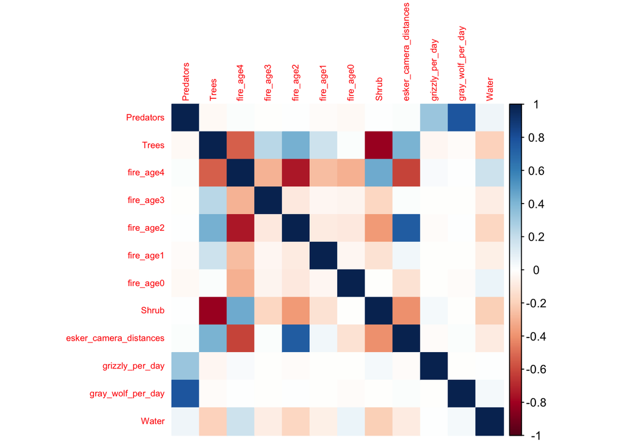

```r
#looking at correlations between variables

## selecting variables for correlation matrix
subset2 <- model_variables %>%
  dplyr::select(32, 33, 2, 3, 4, 5, 6, 8, 25, 28, 29, 11) %>%
  dplyr::mutate(Predators = as.numeric(Predators))

# Compute correlation matrix
cor_matrix2 <- cor(subset2, use = "complete.obs")

corrplot(cor_matrix2, method = "color", tl.cex = 0.6)
```